# Copy the Masters

Mini-project

**Note**

I recommend completing this mini-project in Quarto or Rmarkdown. Please include your code!

## Deliverables

| Component | Brief Description | Due Date |
| --- | --- | --- |
| Picking a Graphic | choice of graphic, and “pseudo-code” of how you think it will be doable | Thursday, May 11 at 11:59pm |
| First Draft | first draft of graphic, around 6 lines of graphics code | Thursday, May 18 at 11:59pm |
| Final Draft | final draft of graphic, as many lines of code as it takes! | Thursday, May 25 at 11:59pm |

For this assignment, we’ll be reproducing graphics from [FiveThirtyEight](https://fivethirtyeight.com/) I chose FiveThirtyEight for a couple of reasons. First, I think they make very clear data graphics. And then perhaps more importantly, they make their data public, so it will be easier for us to reproduce their work.

## Picking a Graphic

For the first step of this assignment, you will be identifying a graphic you want to reproduce. Start at the [Our Data](https://data.fivethirtyeight.com/) page and find a graphic that interests you and you think is possible to reproduce. This is mostly a “thinking step,” rather than a coding one, although you may want to start playing around in `ggplot2` to see if your guess is right. Plots that will be easier to reproduce are the more standard ones (histograms, line charts, scatterplots, etc).

**Warning**

Some graphics in FiveThirtyEight are created with d3.js to incorporate interactivity. If the plot you select contains an interactivity component, please select a standstill snapshot of the graphic to recreate.

I looked through quickly and thought the following would be pretty doable:

- The House and Senate are older than ever before, from [Congress Today Is Older Than It’s Ever Been](https://fivethirtyeight.com/features/aging-congress-boomers/) (others look doable, too)
- Cleveland’s settlement amounts rose after Rice’s death, from [Cities Spend Millions On Police Misconduct Every Year. Here’s Why It’s So Difficult to Hold Departments Accountable](https://fivethirtyeight.com/features/police-misconduct-costs-cities-millions-every-year-but-thats-where-the-accountability-ends/)
- More players transfer to the US than to any other country from [American Chess Is Great Again](https://fivethirtyeight.com/features/american-chess-is-great-again/)
- Hurricane Maria and Puerto Rico got comparatively little online coverage, from [The Media Really Has Neglected Puerto Rico](https://fivethirtyeight.com/features/the-media-really-has-neglected-puerto-rico/) (others look doable, too)
- Do you think that society puts pressure on men in a way that is unhealthy or bad for them?, from [What Do Men Think It Means To Be A Man?](https://fivethirtyeight.com/features/what-do-men-think-it-means-to-be-a-man/) (others look doable, too)
- Trump is less popular than leading Democratic candidates, from [The Democratic Presidential Candidates Are Becoming Less Popular](https://fivethirtyeight.com/features/the-democratic-presidential-candidates-are-becoming-less-popular/)

Potentially doable:

- [The LeBron James Decision-Making Machine](https://fivethirtyeight.com/features/the-lebron-james-decision-making-machine/)
- Did Americans support impeaching Trump?, from [Did Americans support removing Trump from office?](https://projects.fivethirtyeight.com/impeachment-polls/) (others look potentially doable, too)
- Sandy-related calls to 311, from [The (Very) Long Tail Of Hurricane Recovery](https://projects.fivethirtyeight.com/sandy-311/)
- Biden’s Ukraine-related media bump is fading, from [The Media Frenzy Around Biden Is Fading](https://fivethirtyeight.com/features/the-media-frenzy-around-biden-is-fading/)
- [50 Years of World Cup Doppelgangers](https://projects.fivethirtyeight.com/world-cup-comparisons/)

On the scale of hard-to-not-doable:

- Peter and Dean are Neck and Neck, from [Rachel’s Season Is Fitting Neatly Into ‘Bachelorette’ History](https://fivethirtyeight.com/features/rachels-season-is-fitting-neatly-into-bachelorette-history/)
- The Rise of the Trinity, from [American Chess Is Great Again](https://fivethirtyeight.com/features/american-chess-is-great-again/)
- Change of Pace, from [Why Some Tennis Matches Take Forever](https://fivethirtyeight.com/features/why-some-tennis-matches-take-forever/)
- Foods that may or may not give you cancer, by [You Can’t Trust What you Read About Nutrition](https://fivethirtyeight.com/features/you-cant-trust-what-you-read-about-nutrition/)

**Note**

All of these may require a bit of data wrangling before you can get to the graphing data part.

You can’t choose either of the first graphic from [Comic Books Are Still Made By Men, For Men And About Men](https://fivethirtyeight.com/features/women-in-comic-books/) because I will be using it as an example.

**Canvas Submission**

- Include a screenshot image of the original selected graphic.
- Include a URL link to your selected graphic.
- Include a quick snapshot and reference for the data set (e.g. `head(data)`).
  - This will require you to figure out how you will access the data (`fivethirtyeight`, `fivethirtyeightdata` or download from [FiveThirtyEight Data](https://data.fivethirtyeight.com/)).
  - You do not need to have done your data management yet, but if any is necessary, it should be included in your “game plan” below.
- Include some sort of “pseudo-code” (game plan) for recreating the graphic.
  - You can do this in multiple different ways: a list of steps, a sketch using [excalidraw.com](https://excalidraw.com/), or outlined code. Just convince me you have a plan of attack for recreating the graph.

## First Draft

Your next step is to do the quick, sketchy version of your graphic in code. Here is an example.

```r
library(tidyverse)
library(ggthemes)
# install.packages('fivethirtyeightdata', repos = 'https://fivethirtyeightdata.github.io/drat/', type = 'source')
library(fivethirtyeightdata)
library(fivethirtyeight)
data(comic_characters)
```

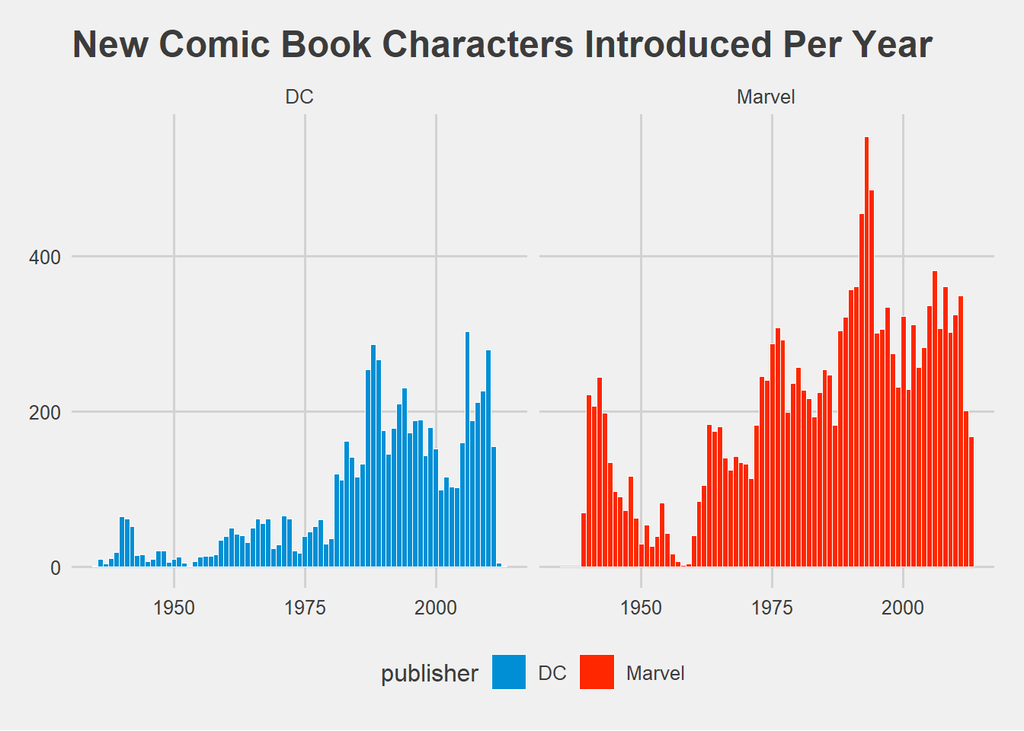

```r
comic_characters |>
  ggplot(aes(x    = year,
             fill = publisher
             )
         ) +
  geom_histogram(binwidth  = 1,
                 color     = "white",
                 linewidth = 0.1
                 ) +
  facet_wrap(~ publisher) +
  theme_fivethirtyeight() +
  scale_fill_manual(values = c("#008fd5", "#ff2700")) +
  labs(title = "New Comic Book Characters Introduced Per Year")
```

For the first draft, I want you to upload a `.html` file knitted from a `.qmd` (or `.Rmd`) file. It doesn’t have to have many lines of code in it (in fact, I think a good draft usually only takes 6 or so lines!), but it should include a version of your visualization that is at least part of the way to reproducing the original graphic. In particular, it should be the right “form” of graph (if the original is a barchart, it should be a barchart, not a scatterplot!). It’s okay if there are more categories than the original, or if the axes are off, etc.

Here’s another example, of an original graphic from FiveThirtyEight and what I would consider a draft of the graphic.

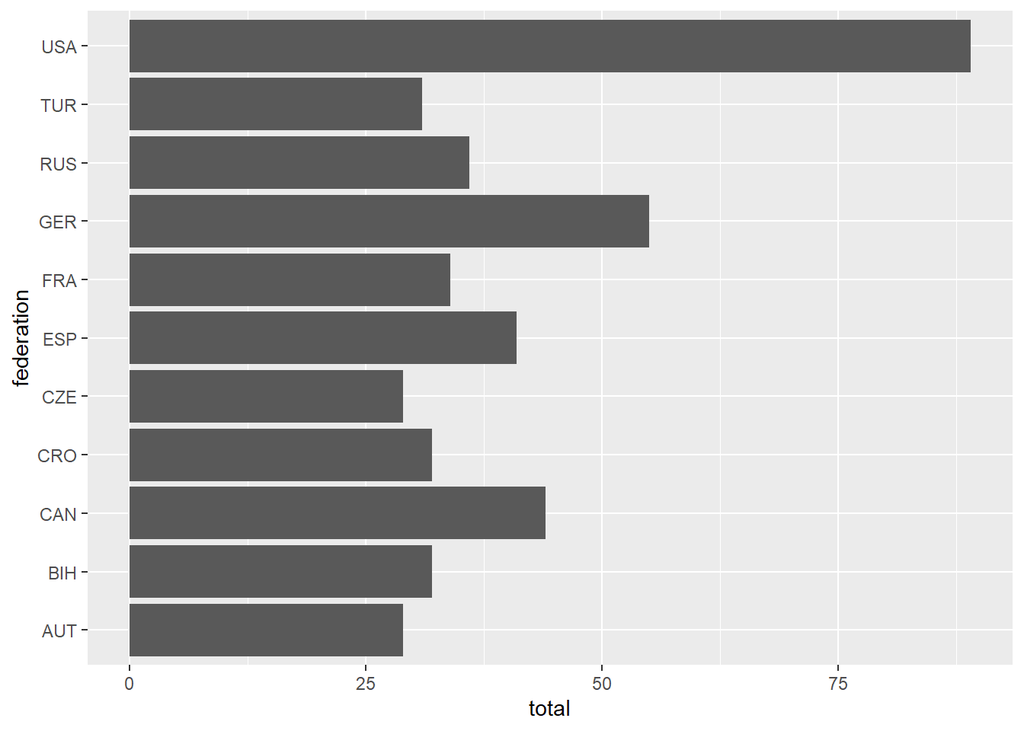

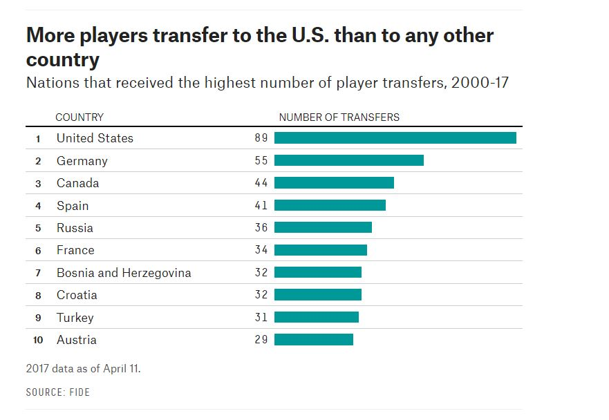

There’s a lot missing in the draft - it doesn’t have the right colors, the names still aren’t right, and the order is off! But it’s the correct “form” of graphic.

**Canvas Submission**

- Include a screenshot image of the original selected graphic.
- Include a URL link to your selected graphic.
- Include your code for creating your first draft (data management & ggplot2).
- Include the image of the first draft of your recreated graphic.

## Final Draft

The last piece is to get your graphic to look as similar to the original as possible.

In addition to your final draft, you should include two short paragraphs:

1. A brief description of what the graphic shows.
2. A critique and reflection of the design principles and choices made when FiveThirtyEight created the graphic, referring to perceptual and design principles discussed in class.

(Optional) Include alt text for your graphic. This can be included into .Rmd `fig.alt =` or .qmd `#| fig-alt:` code chunks (see slides from Week 5 for guidelines).

## Final Submission Rubric

To meet the “satisfactory” requirements for the contract, this project must:

- be turned in on time (or within the agreed upon time by 24 hour late tokens submitted **prior** to the due date),
- include all components described above
- Meet quality guidelines laid out in the following rubric (all 2s and above for each element and demonstration of additional considerations)

**Warning**

Please include ALL code used to complete the recreation of the graphic.

[output not shown]

## Acknowledgements

I would like to acknowledge [Amelia McNamara](https://www.amelia.mn/STAT336/copy-the-masters.html) for the original activity.